# Visual Analytics

A new article created using the Distill format.

Clement Ong (Singapore Management University)  
2022-01-27

### Contents

Introduction

# Introduction

This take home exercise will explore how to create two visualizations using R, namely:

- **Pareto Chart**
- **Population Pyramid**

Each of these charts will represent the Superstore and the Department of Statistics dataset respectively.More about their datasets will be explained in their respective sessions

This article will also explain the considerations and steps taken to create the visuals for each case study.

Lets us begin!

# 2.0 Required Libraries

The following code chunk will check if the required libraries are installed first before loading them into the R environment.

```r
packages = c('tidyverse', 'readxl','knitr','kableExtra')
for (p in packages){
  if(!require(p,character.only = T)){
    install.packages(p)
  }
  library(p, character.only = T)
}
```

# 3.0 Case Study 1 : Superstore Dataset

### 3.1 Case Study Overview and Dataset

The SuperStore dataset contains data on order details of customers for orders of a superstore in the US. This includes order, return and shipping information. For the this first case study, we will conduct an **analysis of returns** which is an analysis about return of a product to allow management to further investigate the reason why these products are being returned.

#### The Task

Build a pareto chart showing the distribution of returns by product sub-category in this super store.

### 3.2 Sketch of Proposed Design

Created by the creator of the “80/20” rule (Vilfredo Pareto), the pareto chart was meant to show the effects of losses based on different casues.

By Ordering the bars from largest to smallest,we can visualise the “20%” that is the most critical. In this casse, factors/categories represented by “taller” bars will on the most left will have the most importance.A cumulative percentage line will give added judgement guidelines. The start of the cumulative line will raise steeply before tipping off to have more of a constant slope.

The transition point will be the “vital few” point. the set of categories identified before the vital point can help management teams to break a bigger problem into parts and identify areas for improvement easily

More about [pareto chart uses](https://blog.minitab.com/en/understanding-statistics/when-to-use-a-pareto-chart)

### 3.4 Data Prepation

Our first step is to read the dataset. Notice that the Superstore dataset is normalised and thus, data tables pertaining to the order and return information would exist in different sheets.

```r
# reading the data
orders <- read_xls("./data/Sample - Superstore.xls", sheet='Orders')
returns <- read_xls("./data/Sample - Superstore.xls", sheet='Returns')
```

With the `tibble` dataframe of orders and returns seperted, we need to join these tables. We can do so using `dplyr` library join functions. The following code chunk uses a left join between returns to orders. The idea is that we are concern with returns and so we will left join returns to orders.

```r
join_table <- left_join(returns, orders,
                        by = c('Order ID' = 'Order ID'))
```

```r
# Check if there are ids that exist in returns but not in orders - there technically should not be the case
join_table[rowSums(is.na(join_table)) >= 0.7,]
```

```
# A tibble: 0 × 22
# … with 22 variables: Returned <chr>, Order ID <chr>, Row ID <dbl>,
#   Order Date <dttm>, Ship Date <dttm>, Ship Mode <chr>,
#   Customer ID <chr>, Customer Name <chr>, Segment <chr>,
#   Country/Region <chr>, City <chr>, State <chr>, Postal Code <dbl>,
#   Region <chr>, Product ID <chr>, Category <chr>,
#   Sub-Category <chr>, Product Name <chr>, Sales <dbl>,
#   Quantity <dbl>, Discount <dbl>, Profit <dbl>
```

Great! It shows that all rows have no missing data!Now we may begin to do some data wrangling!

The code chunk below does the following as describe below:

- Firstly, we will group the return orders by sub-category and then count the number of return orders in each of the sub-categories respectively using the `group_by` and `summarise` function.
- Secondly, It will then sort in descending order where the largest value will represent the most left factor (Factor with the highest frequency) using the `arrange` function.
- Finally, the `mutate` function will be used to calculate the cumulative frequency and the cumulative percentage points.
- Dont forget to ungroup once you use group by!

```r
# Creating Pareto dataframe
pareto_df <- join_table %>%
                group_by(`Sub-Category`) %>%
                  summarise('Returns'=n()) %>%
                  arrange(desc(Returns)) %>%
                  mutate(cumfreq = cumsum(Returns), cumperc = cumfreq/nrow(join_table) * 100) %>%
                      ungroup()
```

```r
# ordering the sub categories as factors
pareto_df$`Sub-Category` = ordered(pareto_df$`Sub-Category`, levels= unlist(pareto_df$`Sub-Category`, use.names = F))
```

### 3.5 Building the Visalisation

To build a visualization, it is important that the graphic is tailored for the audience such that it brings the intended message across. Notice that while we have prepared the values that will be used on the pareto chart, we need to create more variables to customize the chart.

The following code junk creates the neccessary variables for chart customization :

1. `N` is the sum or total number of return orders
2. `y2` is the secondary y-axis label that will be used for the pareto line chart
3. `nr` is the number of rows in the Pareto data frame
4. `Df_ticks` contain the data frame that have three columns. Each of this column will represent the coordinates that will be used to help construct the secondary axis using geom segment object.

#### 3.5.1 Building Graph Ticks

```r
# configuring pareto ticks and labels
N = sum(pareto_df$Returns)
y2 <- c("  0%", " 10%", " 20%", " 30%", " 40%", " 50%", " 60%", " 70%", " 80%", " 90%", "100%")
nr <- nrow(pareto_df)
Df_ticks <- data.frame(xtick0 = rep(nr +.6, 11), xtick1 = rep(nr +.8, 11),
                       ytick = seq(0, N, N/10))
```

Finally! Its all ready! Lets build the graph!

#### 3.5.2 Building the Pareto Chart

This section will explain how the Pareto chart is being build.

To build the Pareto chart there are a few components and geom objects we need to be familiar with.

The core components come from the ggplot2 library. It’s uses in this segment is explained as follow:

- geom_bar : used to create bar plots. It makes use underlying function stat_count() which counts the number of cases at each x position
  - Note that this should not be confused with geom_col() which uses stat_identity() instead.
  - Essentially the two are the same if i use geom_bar(stat=“identity”)
- geom_path : connects the observation in order in which they appear in the data. This function will help to connect observations in original order
  - Note that this is different from geom_line. Geom_line instead connect observations in order by the x value in the data.
  - More can be found here : (geom_path versus geom_line)[http://www.kaiyin.co.vu/2014/05/ggplot2-difference-between-geomline-and.html]
- geom_point : Used to create geom_point which is a scatter plot to display relationship between two continuous variables There are other variations like geom_jitter or geom_count. In this case we will focus on using geom_point

Knowing the components of a Pareto chart, we can start to work on the parameters of these objects. The usage of parameters are as described below:

- [aes (aesthetics)](https://beanumber.github.io/sds192/lab-ggplot2.html#Geometric_Objects_and_Aesthetics) : this parameters maps a visual cue to a variable. Some of these include specifying the x and y axis values, fill (inside), color, position..
  - For our case, we will adjust these parameters to help with with the graphical output
- scale_y_continuous and scale_x_discrete : used for scaling of the number of breaks (for y axis) and the x sub-category labeling
- ‘guides’ : are extra labels like legends that can be used to give more information. We will be removing this as we do not have mutliple facet categories or color coding. Thus will not be neccessary. We will instead make do with a secondary axis using geom_segment (segmentation) to customise the chart
- annotate : allow you to add all kinds of shapes or text you want to your graph
  - Note: annotate is a simplier and more efficient alternative to reduce code length when wanting to add extra graphical compoenents to the graph
  - 2 annotations were added to the graph, one is to create a rectangle of white background for the text space while the other is to create the secondary axis y labels
- geom_segment : Draw a straight line as your state the coordinates on the cardtesian plain in which it would appear
  - the parameters x, xend, y, yend specify where the line will start or end on the x and y axis respectively
  - below we are using 2 geom segements to create the secondary y-axis line, followed by the ticks line that spans from the secondary y-axis to the text annotation (secondary axis y label)
- labs : specifices the labels of the chart , this includes the title, subtitle, x and y axis-titles
- themes() : themes function is a way to customize all non-data display. We will be using the complete theme: theme_bw() and further specific the text size of both the x and y axis text and title labels.

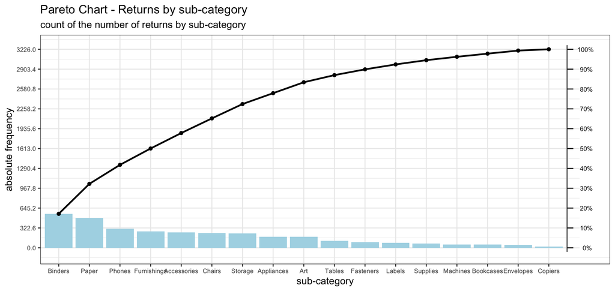

```r
# need to adjust
# the pareto chart

ggplot(pareto_df, aes(x=`Sub-Category`, y=Returns)) +
  geom_bar(aes(y=Returns), fill='lightblue', stat="identity") +
  geom_path(aes(y=cumfreq, group=1), color="black", size=0.9) +
  geom_point(aes(x=`Sub-Category`, y = cumfreq),color="black") + # pch is typ of pointer
      scale_y_continuous(breaks=seq(0, N, N/10))  +
      scale_x_discrete(breaks = pareto_df$`Sub-Category`) +
      guides(fill = FALSE, color = FALSE, scale="none") +
      annotate("rect", xmin = nr + 1, xmax = nr + 2,
               ymin = -.03 * N, ymax = N * 1.02, fill = "white") + # create the space
      annotate("text", x = nr +1.2, y = seq(0, N, N/10), label = y2, size = 2.5) + # create the labels
      geom_segment(x = nr + 0.6, xend = nr+0.6, y = -.02 * N, yend = N * 1.02 , color = "grey50") + # create the line
      geom_segment(data = Df_ticks, aes(x = xtick0, y = ytick, xend = xtick1, yend = ytick)) +  # create the ticks

      labs(title="Pareto Chart - Returns by sub-category", subtitle="count of the number of returns by sub-category",
           x="sub-category", y="absolute frequency") +
      theme_bw() +
      theme(axis.text.x = element_text(size=rel(0.8))
            ,axis.title.x = element_text(size=rel(1))
            ,axis.text.y = element_text(size=rel(0.8))
            ,axis.title.y = element_text(size=rel(1))
            )
```

### 3.6 Conclusion and Interpretation

# 4.0 Case Study 2 : Singapore Residents Singstat Dataset

### 4.1 Case Study Overview and Dataset

The [Singapore Residents by Planning Area/Subzone,AgeGroup.Sex and Type of Dwelling Singstat Dataset](https://www.singstat.gov.sg/find-data/search-by-theme/population/geographic-distribution/latest-data) representing the number of people staying in different regions of Singapore with age cohort, sex and dwelling details

#### The Task

Build an age-sex pyramid representing the demographic structure of Singapore by age cohort and gender

### 4.2 Sketch of Proposed Design

Typically it shows a continuous stacked horiztonal histogram bar. The population size is on the x-axis while the age-cohort would be presented on the y-axis. The height of each bar typically represents either an absolute frequency or a percentage of the number of people in each age cohort.

### 4.4 Data Prepation

```r
#Reading the Data
respo_df <- read_csv("./data/respopagesextod2021.csv")
```

Next, we will encode the dataset into the respective age bins (categories) in an ordered manner, with those of ages 0 being the smallest and over 90 being the largest value in the scale.

```r
respo_df$AG <- factor(respo_df$AG, ordered=TRUE ,levels=c("0_to_4","5_to_9","10_to_14",
                                                          "15_to_19","20_to_24","25_to_29",
                                                          "30_to_34","35_to_39","40_to_44",
                                                          "45_to_49","50_to_54","55_to_59",
                                                          "60_to_64","65_to_69","70_to_74",
                                                          "75_to_79","80_to_84","85_to_89","90_and_over"))
```

Upon encoding the categories the relevant data will be extracted from the dataset. AG (Age), Sex and Pop will be selected and grouped by AG and Sex. The corresponding values for these groups will be the total sum of the Pop of these groups and the data will be ordered by Sex and AG. The values will then be ungrouped for data visualization

```r
# GET DATA
ag_df <- respo_df %>%
  select(AG, Sex, Pop) %>%
  group_by(AG,Sex) %>%
  summarise(Total = sum(Pop)) %>%
  arrange(Sex,AG) %>%
  ungroup()
```

Next, the total Pop size of males for each group will be multiplied by a factor of -1 to vertically flip the values from the positive x-axis to the negative x-axis.

```r
# All males are negative so they go to the left
ag_df$Total <- ag_df$Total/1000
ag_df$Total <- ifelse(ag_df$Sex == "Males", -1*ag_df$Total, ag_df$Total)
```

### 4.5 Building the Visalisation

The following code junk creates the neccessary variables for chart customization :

#### 4.5.1 Building Graph Ticks

```r
# creating ticks
N = max(ag_df$Total)
```

#### 4.5.2 Building the Population Pyramid Chart

This section will explain how the Population Pyramid Chart was build.

To build the Population Pyramid chart there are a few components and geom objects we need to be familiar with.

The core components come from the ggplot2 library. It’s uses in this segment is explained as follow:

- geom_bar : used to create bar plots. It makes use underlying function stat_count() which counts the number of cases at each x position
  - Note that this should not be confused with geom_col() which uses stat_identity() instead.
  - Essentially the two are the same if i use geom_bar(stat=“identity”)
- scale_y_continuous and scale_x_discrete : used for scaling of the number of breaks (for y axis) and the x sub-category labeling
- labs : specifices the labels of the chart , this includes the title, subtitle, x and y axis-titles
- themes() : themes function is a way to customize all non-data display. We will be using the complete theme: theme_bw() and further specific the text size of both the x and y axis text and title labels.

[figure not shown]

```r
# Graph itself
ggplot(ag_df, aes(x = AG, fill = Sex,
                 y = Total)) +
  geom_bar(stat = "identity") +
  scale_y_continuous(n.breaks=18, labels=abs, limits = N * c(-1,1))+
  coord_flip() +
  scale_colour_manual(values = c("pink", "steelblue"),
                      aesthetics = c("colour", "fill")) +
  labs(title="Constrictive Population Pyramid of Ang Mo Kio Residents ", subtitle="Total number of Ang Mo Kio Residents by their respective age groups follows a bee hive distribution",
       x="Age Groups", y="Number of People (In Thousands)") +
  theme_bw()
```

### 4.6 Conclusion and Interpretation

Population pyramids are important graphical representation to undestand the composition of population memebers.

it is typically visualised by grouping the population memebers into age cohorts and diving by gender. In other words, the age-sex struture of specific populations. This makes it easy for demographers to compare the difference between male and female populations and the structure of the population at any given moment. Demographers/researchers typically use this to study the trend of populations relating to the fertility and mortality.

There are three trneds in population pyramids they are typically: - expansive - constrictive - stationary

#

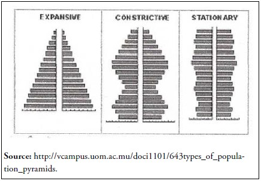

We shall focus our efforts in explaining the trend that is reflected in our plot.

#### Chart interpretation and conclusion

The Singapore population trend across all regions for both gender is depicted to follow a constrictive trend with its ‘beehive’ shaped.

-It has a shape with a wide area in the middle covering the middle age group from 15 to 64. -It has a narrow base with the younger age cohort (typically below 15) -It has a narrow tip with the elderly age group (typically over age of 64)

As observed in our population pyramid, there is observed to be lower mortality and fertility rate. This translate to lower birth rates (lesser in the younger cohort) and death rates (lesser in the elderly age cohorts).Population members mostly reside in the middle age group and elderly people compared to younger age groups.

Overall, the population pyramid with a constrictive trend represents a population that is shrinking. With a constant fertility rate and a large middle age group which would grow old eventually, will result in a shrinking population.

Research have shown that constrictive population pyramids are typical of countries with higher socio-economic developement who have access to higher quality education and accessible healthcare avalaible to a large proportion of the population.

These include standard of living simialr to that of singapore like japan germany and italty

## 5 Benefits of using R over Tableau